# 25_component_analysis_matrix_factorization

### [Example: blind source separation with ICA](https://scikit-learn.org/stable/auto_examples/decomposition/plot_ica_blind_source_separation.html)

- Dataset: 3 instruments playing simulateously + 3 microphones recording the mixture. ICA is used to recover each source.
- Note: PCA will fail - the correlated signals are non-Gaussian.

```python
import numpy as np
import matplotlib.pyplot as plt
from scipy import signal
from sklearn.decomposition import FastICA, PCA
```

```python
np.random.seed(0)
n_samples = 2000
time      = np.linspace(0, 8, n_samples)

# 1 = sinusoid; 2 = square; 3 = sawtooth
s1        = np.sin(2 * time)
s2        = np.sign(np.sin(3 * time))
s3        = signal.sawtooth(2 * np.pi * time)

# add noise, standardize, then mix
S  = np.c_[s1, s2, s3]
S += 0.2 * np.random.normal(size=S.shape)
S /= S.std(axis=0)
A  = np.array([[1.0, 1.0, 1.0],
               [0.5, 2.0, 1.0],
               [1.5, 1.0, 2.0]])
X  = np.dot(S, A.T)
```

```python
# ICA: reconstruct signals; get est. mix matrix
ica = FastICA(n_components=3)
S_  = ica.fit_transform(X)
A_  = ica.mixing_

# prove ICA is applicable by undoing the unmixing
assert np.allclose(X, np.dot(S_, A_.T) + ica.mean_)

# PCA: reconstruct signals using orthogonal components
pca = PCA(n_components=3)
H = pca.fit_transform(X)
```

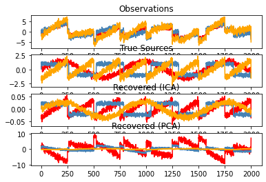

```python
models = [X, S, S_, H]
names = ['Observations',
         'True Sources',
         'Recovered (ICA)',
         'Recovered (PCA)']
colors = ['red', 'steelblue', 'orange']

for ii, (model, name) in enumerate(zip(models, names), 1):
    plt.subplot(4, 1, ii)
    plt.title(name)
    for sig, color in zip(model.T, colors):
        plt.plot(sig, color=color)

#plt.tight_layout()
```

### [Non-Negative matrix factorization (NMF/NNMF)](https://scikit-learn.org/stable/modules/generated/sklearn.decomposition.NMF.html#sklearn.decomposition.NMF)

- Assumes all data & components are not negative. It can be used instead of PCA.
- NMF decomposes $X$ into two matrices $W$ and $H$ by optimizing the distance $d$ between $X$ and the matrix product $W.H$.
- The **squared Frobenius norm** is the most commonly used distance function. It is an extension of the *Euclidean norm* to matrices: $d_{\mathrm{Fro}}(X, Y) = \frac{1}{2} ||X - Y||_{\mathrm{Fro}}^2 = \frac{1}{2} \sum_{i,j} (X_{ij} - {Y}_{ij})^2$.
- Other distance function options:
  - The **Kullback-Leibler (KL) divergence**: $d_{KL}(X, Y) = \sum_{i,j} (X_{ij} \log(\frac{X_{ij}}{Y_{ij}}) - X_{ij} + Y_{ij})$
  - The **Itakura-Saito (IS) divergence**: $d_{IS}(X, Y) = \sum_{i,j} (\frac{X_{ij}}{Y_{ij}} - \log(\frac{X_{ij}}{Y_{ij}}) - 1)$
  - (These three are special cases of the **beta divergence family** with $\beta$=2,1,0 respectively): $d_{\beta}(X, Y) = \sum_{i,j} \frac{1}{\beta(\beta - 1)}(X_{ij}^\beta + (\beta-1)Y_{ij}^\beta - \beta X_{ij} Y_{ij}^{\beta - 1})$
- When carefully constrained, NMF can build a parts-based representation of a dataset - resulting in *interpretable models*.
- `init` determines the initialization method:
  - **NNDSVD** (Non-negative double singular value decomposition) is based on two SVD processes - one approximating a data matrix, another approximating positive sections of the resulting *partial SVD factors*. This is best suited for *sparse factorization*.
  - **NNDSVDa** sets all zeros equal to the *mean of all data elements*.
  - **NNDSVDar** sets all zeros to random pertubations < the data mean, divided by 100. This is best suited for *dense factorization*.
  - **"random"**
- L1 & L2 priors can be added to the loss function for regularization. The L2 prior uses the Frobenius norm; the L1 prior uses an element-wise L1 norm. `l1_ratio` controls the L1/L2 combination; `alpha` controls regularization "intensity".
- NMF regularizes $W$ and $H$ by default. `regularization` provides fine-tuned control. (Only $W$, only $H$, or both.
- NMF has two solvers: Coordinate Descent (`cd`) and Multiplicative Update (`mu`). The `cd` solver can only optimize the Frobenius norm. The `mu` solver can optimize every beta-divergence and is significantly faster on KL and IS divergences.

### [Example: plot Beta-divergence loss functions using the `mu` solver](https://scikit-learn.org/stable/auto_examples/decomposition/plot_beta_divergence.html#sphx-glr-auto-examples-decomposition-plot-beta-divergence-py)

```python
import numpy as np
import matplotlib.pyplot as plt
from sklearn.decomposition._nmf import _beta_divergence
```

```
(0.0, 4.0, 0.0, 3.0)
```

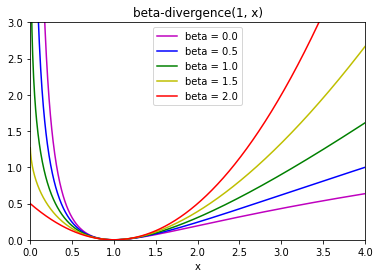

```python
x = np.linspace(0.001, 4, 1000)
y = np.zeros(x.shape)

colors = 'mbgyr'
for j, beta in enumerate((0., 0.5, 1., 1.5, 2.)):
    for i, xi in enumerate(x):
        y[i] = _beta_divergence(1, xi, 1, beta)
    name = "beta = %1.1f" % beta
    plt.plot(x, y, label=name, color=colors[j])

plt.xlabel("x")
plt.title("beta-divergence(1, x)")
plt.legend(loc=0)
plt.axis([0, 4, 0, 3])
```

### Latent Dirichlet Allocation (LDA)

- Another generative model for collection of discrete data. Can also be used to discover topics from document collections. Graphically:
  - The corpus is a set of $D$ documents with $K$ topics; a document is a sequence of $N$ words.
  - The boxes represent *repeated sampling*.
  - Shaded = observable; unshaded = hidden (latent).

[figure not shown]

- Latent variables model the *random mix of topics in the corpus, and distribution of words in the documents*.
- The goal of LDA is to use the observed words to infer the hidden topic structure.
- When LDA is applied to a *document-term* matrix, the matrix will be decomposed into *topic-term* (stored in `components_`) and *document-topic* matrices. the *document-topic* matrix can be found using the `transform` method.
- LDA supports `partial_fit` for handling sequential fetching.

### [Example: Topic extraction with NMF & LDA](https://scikit-learn.org/stable/auto_examples/applications/plot_topics_extraction_with_nmf_lda.html#sphx-glr-auto-examples-applications-plot-topics-extraction-with-nmf-lda-py)

- NMF is applied using both the *Frobenius norm* and the *KL Divergence*.

```python
from time import time
import matplotlib.pyplot as plt

from sklearn.feature_extraction.text import TfidfVectorizer as TV
from sklearn.feature_extraction.text import CountVectorizer as CV
from sklearn.decomposition import NMF, LatentDirichletAllocation as LDA
from sklearn.datasets import fetch_20newsgroups
```

```python
n_samples, n_features, n_components, n_top_words = 2000, 1000, 10, 20
```

```python
def plot_top_words(model, feature_names, n_top_words, title):
    fig, axes = plt.subplots(2, 5, figsize=(30, 15), sharex=True)
    axes = axes.flatten()

    for topic_idx, topic in enumerate(model.components_):
        top_features_ind = topic.argsort()[:-n_top_words - 1:-1]
        top_features     = [feature_names[i] for i in top_features_ind]
        weights          = topic[top_features_ind]

        ax = axes[topic_idx]
        ax.barh(top_features, weights, height=0.7)
        ax.set_title(f'Topic {topic_idx +1}',
                     fontdict={'fontsize': 30})
        ax.invert_yaxis()
        ax.tick_params(axis='both', which='major', labelsize=20)
        for i in 'top right left'.split():
            ax.spines[i].set_visible(False)
        fig.suptitle(title, fontsize=40)

    plt.subplots_adjust(top=0.90, bottom=0.05, wspace=0.90, hspace=0.3)
```

```python
t0 = time()
data, _ = fetch_20newsgroups(shuffle=True, random_state=1,
                             remove=('headers', 'footers', 'quotes'),
                             return_X_y=True)
data_samples = data[:n_samples]
print("done in %0.3fs." % (time() - t0))
```

```
done in 0.858s.
```

```python
tfidf_vectorizer = TV(max_df=0.95,
                      min_df=2,
                      max_features=n_features,
                      stop_words='english')
t0 = time()
tfidf = tfidf_vectorizer.fit_transform(data_samples)
print("done in %0.3fs." % (time() - t0))
```

```
done in 0.216s.
```

```python
# Use tf (raw term count) features for LDA.
tf_vectorizer = CV(max_df=0.95,
                   min_df=2,
                   max_features=n_features,
                   stop_words='english')
t0 = time()
tf = tf_vectorizer.fit_transform(data_samples)
print("done in %0.3fs." % (time() - t0))
```

```
done in 0.211s.
```

```python
# Fit the NMF model
t0 = time()
nmf = NMF(n_components=n_components,
          random_state=1,
          alpha=.1,
          l1_ratio=.5).fit(tfidf)
print("done in %0.3fs." % (time() - t0))
```

```
done in 0.301s.
```

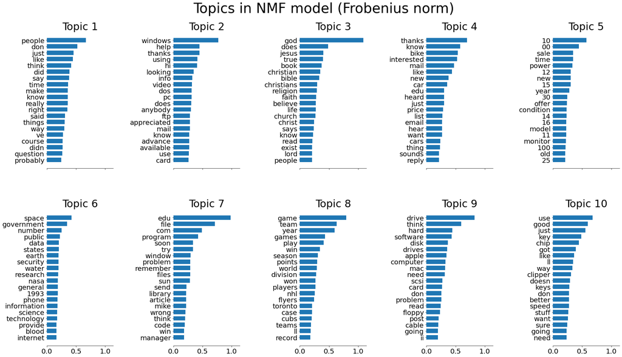

```python
tfidf_feature_names = tfidf_vectorizer.get_feature_names()
plot_top_words(nmf, tfidf_feature_names, n_top_words,
               'Topics in NMF model (Frobenius norm)')
```

```python
# Fit the NMF model
t0 = time()
nmf = NMF(n_components=n_components,
          random_state=1,
          beta_loss='kullback-leibler',
          solver='mu',
          max_iter=1000,
          alpha=.1,
          l1_ratio=.5).fit(tfidf)
print("done in %0.3fs." % (time() - t0))
```

```
done in 1.183s.
```

[figure not shown]

```python
tfidf_feature_names = tfidf_vectorizer.get_feature_names()
plot_top_words(nmf, tfidf_feature_names, n_top_words,
               'Topics in NMF model (generalized Kullback-Leibler divergence)')
```

```python
lda = LDA(n_components=n_components,
          max_iter=5,
          learning_method='online',
          learning_offset=50.,
          random_state=0)
t0 = time()
lda.fit(tf)
print("done in %0.3fs." % (time() - t0))
```

```
done in 2.433s.
```

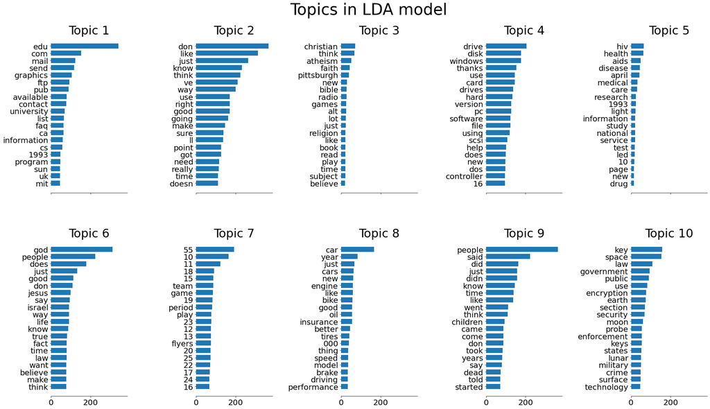

```python
tf_feature_names = tf_vectorizer.get_feature_names()
plot_top_words(lda, tf_feature_names, n_top_words, 'Topics in LDA model')
```